# Laboratorio_Descenso_del_Gradiente (1)

```python
import random
import numpy as np
import matplotlib.pyplot as plt
from mpl_toolkits.mplot3d import Axes3D
import math
import pandas as pd
```

**1. Según tales funciones, grafique las funciones usando la función meshgrid.(10pts)**

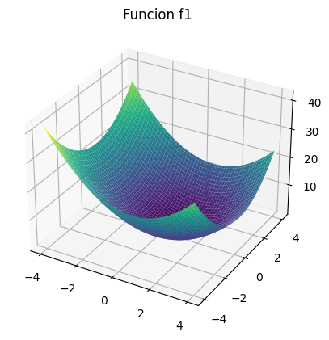

```python
# Graficar:
#   f1(x1, x2) = (x1 - 0.7)**2 + (x2 - 0.5)**2    con x1, x2 ∈[-4, 4].

# Definimos las funciones
def f1(x1, x2):
    return (x1 - 0.7)**2 + (x2 - 0.5)**2

# Creamos la cuadrícula de valores para x1 y x2
x1Vals = np.linspace(-4, 4, 100)
x2Vals = np.linspace(-4, 4, 100)
x1, x2 = np.meshgrid(x1Vals, x2Vals)

# Evaluamos la función en cada punto de la cuadrícula
z = f1(x1, x2)

# Creamos la figura 3D
fig = plt.figure()
ax = fig.add_subplot(111, projection='3d')

# Graficamos la superficie 3D
ax.plot_surface(x1, x2, z, cmap='viridis')
ax.set_title('Funcion f1')

# Mostramos el gráfico
plt.show()
```

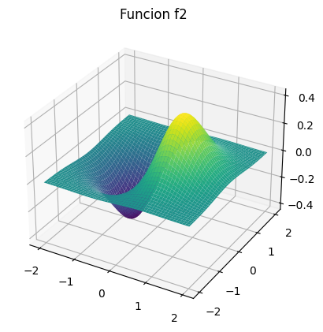

```python
# Graficar:
#   f2(x1, x2) = x1𝑒**(−x1**2 − x2**2)            con x1, x2 ∈[-2, 2].

# Definimos las funciones
def f2(x1, x2):
    return x1*np.exp(-(x1**2 + x2**2))

# Creamos la cuadrícula de valores para x1 y x2
x1Vals = np.linspace(-2, 2, 100)
x2Vals = np.linspace(-2, 2, 100)
x1, x2 = np.meshgrid(x1Vals, x2Vals)

# Evaluamos la función en cada punto de la cuadrícula
z = f2(x1, x2)

# Creamos la figura 3D
fig = plt.figure()
ax = fig.add_subplot(111, projection='3d')

# Graficamos la superficie 3D
ax.plot_surface(x1, x2, z, cmap='viridis')
ax.set_title('Funcion f2')

# Mostramos el gráfico
plt.show()
```

**2. Implemente el algoritmo del descenso del gradiente, para cada función. (90 pts)**

a)

$ f_1(x, y) = (x - 0.7)^2 + (y - 0.5)^2 $

Paso 1: Derivar la función con respecto a x, tratando y como una constante:

$ \frac{\partial f}{\partial x} = x^2-1.4x+y^2+0.74-y $

$ \frac{\partial f}{\partial x} = 2x - 1.4 $

$ \frac{\partial f}{\partial x} = 2(x - 0.7) $

Paso 2: Derivamos respecto a y: $ \frac{\partial}{\partial y} = 2y-1 $

$ \frac{\partial}{\partial y} = 2(y-0,5) $

$ f_2(x, y) = x \cdot e^{-x^2-y^2} $

Paso 1: Derivar la función con respecto a x, tratando y como una constante: $ \frac{\partial f}{\partial x} = x \cdot e^{-x^2-y^2} $

Paso 2: Aplicar la regla del producto y la regla de la cadena para derivar la función: $ \frac{\partial f}{\partial x} = (1 \cdot e^{-x^2-y^2}) + (x \cdot (-2x)e^{-x^2-y^2}) $

Paso 3: Simplificar la derivada parcial: $ \frac{\partial f}{\partial x} = e^{-x^2-y^2} - 2x^2e^{-x^2-y^2} $

Paso 4: Derivamos respecto a y: $ \frac{\partial f}{\partial y} = x \cdot e^{-x^2-y^2} $

Para calcular la derivada parcial de ( f(x, y) ) respecto a ( y ), aplicamos la regla del producto y la regla de la cadena.

$ \frac{\partial f(x, y)}{\partial y} = x \cdot \frac{\partial}{\partial y} \left( e^{-x^2-y^2} \right) $

$ \frac{\partial}{\partial y} \left( e^{-x^2-y^2} \right) = -2y \cdot e^{-x^2-y^2} $

$ \frac{\partial f(x, y)}{\partial y} = x \cdot \left( -2y \cdot e^{-x^2-y^2} \right) $

$ \frac{\partial f(x, y)}{\partial y} = -2xy \cdot e^{-x^2-y^2} $

```python
# Punto 2.a
# Derivadas parciales

def derivada_x1_f1(x1, x2):
  return 2 * (x1 - 0.7)

def derivada_x2_f1(x1, x2):
  return 2 * (x2 - 0.5)

def descenso_gradiente_f1(learning_rate):
  # Inicialización de los valores
  x1 = random.randint(-40, 40)/10
  x2 = random.randint(-40, 40)/10
  iteracion = 0
  puntoMinimo = [0.7, 0.5]

  # Parámetros del algoritmo
  num_iteraciones = 100

  # Bucle de optimización
  for i in range(num_iteraciones):
    ax.scatter(x1, x2, f1(x1, x2), s=100, c='red')
    if (f1(x1, x2) <= 0.001):
      break
    # Cálculo de las derivadas parciales de la función en el punto actual
    df_dx1 = derivada_x1_f1(x1, x2)
    df_dx2 = derivada_x2_f1(x1, x2)

    # Actualización de los valores usando el descenso del gradiente
    x1 = x1 - learning_rate * df_dx1
    x2 = x2 - learning_rate * df_dx2

    # Restricción de los valores [-4,4]
    x1 = np.clip(x1, -4, 4)
    x2 = np.clip(x2, -4, 4)

    iteracion += 1

  # Resultados
  print("La cantidad de iteraciones realizadas es: ", iteracion)
  print("El punto de convergencia alcanzado es: ", x1, x2, f1(x1, x2))
  #Igualamos estas derivadas parciales a cero y resolvemos para x1 y x2:

  #2(x1 - 0.7) = 0 -> x1 = 0.7
  #2(x2 - 0.5) = 0 -> x2 = 0.5

  #Por lo tanto, el punto mínimo de f1 se encuentra en (0.7, 0.5).
  if(round(x1, 1) == puntoMinimo[0] and round(x2, 1) == puntoMinimo[1]):
    print("Convergio al punto correcto?", True)
  else:
    print("Convergio al punto correcto?", False)

#==============================================================================

def derivada_x1_f2(x1, x2):
  return (1 - 2 * x1**2) * np.exp(-x1**2 - x2**2)

def derivada_x2_f2(x1, x2):
  return -2 * x1 * x2 * np.exp(-x1**2 - x2**2)

def descenso_gradiente_f2(learning_rate):
  # Inicialización de los valores
  x1 = random.randint(-20, 20)/10
  x2 = random.randint(-20, 20)/10
  iteracion = 0
  puntoMinimo = [-1, 0]

  # Parámetros del algoritmo
  num_iteraciones = 100

  # Bucle de optimización
  for i in range(num_iteraciones):
    ax.scatter(x1, x2, f2(x1, x2), s=100, c='red')
    if (f2(x1, x2) <= 0.001):
      break
    # Cálculo de las derivadas parciales de la función en el punto actual
    df_dx1 = derivada_x1_f2(x1, x2)
    df_dx2 = derivada_x2_f2(x1, x2)

    # Actualización de los valores usando el descenso del gradiente
    x1 = x1 - learning_rate * df_dx1
    x2 = x2 - learning_rate * df_dx2

    # Restricción de los valores [-2,2]
    x1 = np.clip(x1, -2, 2)
    x2 = np.clip(x2, -2, 2)

    iteracion += 1

  # Resultados
  print("La cantidad de iteraciones realizadas es: ", iteracion)
  print("El punto de convergencia alcanzado es: ", x1, x2, f2(x1, x2))
  if(round(x1, 1) == puntoMinimo[0] and round(x2, 1) == puntoMinimo[1]):
    print("Convergio al punto correcto?", True)
  else:
    print("Convergio al punto correcto?", False)
  print("Grafica de los puntos recorridos")
```

[output not shown]

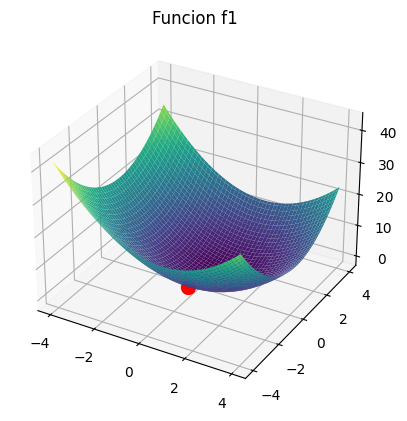

```python
# Punto B Funcion F1

# Creamos la cuadrícula de valores para x1 y x2
x1Vals = np.linspace(-4, 4, 100)
x2Vals = np.linspace(-4, 4, 100)
x1, x2 = np.meshgrid(x1Vals, x2Vals)

# Evaluamos la función en cada punto de la cuadrícula
z = f1(x1, x2)

# Creamos la figura 3D
fig = plt.figure()
ax = fig.add_subplot(111, projection='3d')

# Graficamos la superficie 3D
ax.plot_surface(x1, x2, z, cmap='viridis')
ax.set_title('Funcion f1')

# Ejecutamos la funcion del descenso del gradiente para F1
descenso_gradiente_f1(0.1)

# Mostramos el gráfico
plt.show()
```

```
La cantidad de iteraciones realizadas es:  23
El punto de convergencia alcanzado es:  0.7243497021772967 0.49291645027569553 0.0006430846728197419
Convergio al punto correcto? True
```

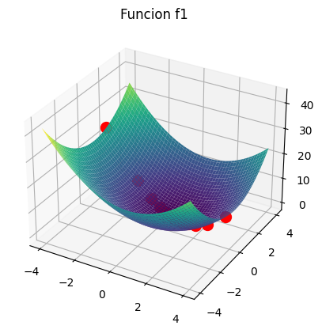

```python
# Punto C Funcion F1

# Creamos la cuadrícula de valores para x1 y x2
x1Vals = np.linspace(-4, 4, 100)
x2Vals = np.linspace(-4, 4, 100)
x1, x2 = np.meshgrid(x1Vals, x2Vals)

# Evaluamos la función en cada punto de la cuadrícula
z = f1(x1, x2)

# Creamos la figura 3D
fig = plt.figure()
ax = fig.add_subplot(111, projection='3d')

# Graficamos la superficie 3D
ax.plot_surface(x1, x2, z, cmap='viridis')
ax.set_title('Funcion f1')

# Ejecutamos la funcion del descenso del gradiente para F1
descenso_gradiente_f1(0.9)

# Mostramos el gráfico
plt.show()
```

Un learning rate demasiado alto puede hacer que el punto se mueva de un lado a otro en lugar de converger suavemente hacia un mínimo. En este caso se puede observar como algunos puntos se alejan del punto minimo, sin embargo, por la forma de la pendiente despues de varias iteraciones llega a encontrar el punto minimo

```
La cantidad de iteraciones realizadas es:  100
El punto de convergencia alcanzado es:  0.8856673782526546 0.1286652434946911 0.1723618767360714
Convergio al punto correcto? False
```

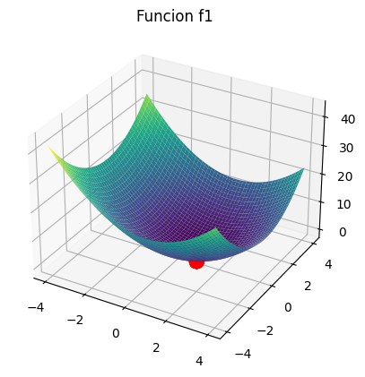

```python
# Punto D Funcion F1

# Creamos la cuadrícula de valores para x1 y x2
x1Vals = np.linspace(-4, 4, 100)
x2Vals = np.linspace(-4, 4, 100)
x1, x2 = np.meshgrid(x1Vals, x2Vals)

# Evaluamos la función en cada punto de la cuadrícula
z = f1(x1, x2)

# Creamos la figura 3D
fig = plt.figure()
ax = fig.add_subplot(111, projection='3d')

# Graficamos la superficie 3D
ax.plot_surface(x1, x2, z, cmap='viridis')
ax.set_title('Funcion f1')

# Ejecutamos la funcion del descenso del gradiente para F1
descenso_gradiente_f1(0.01)

# Mostramos el gráfico
plt.show()
```

Si se utiliza un learning rate muy bajo, el algoritmo de descenso de gradiente se volverá muy lento y requerirá muchas iteraciones para converger a una solución óptima. Esto es porque el tamaño de los pasos será muy pequeño, y el algoritmo tardará mucho tiempo en explorar el espacio de búsqueda. En este caso se puede observar que los pasos son tanb pequeños que no se llega a alcanzar el punto minimo en la mayoria de los casos, solo en los casos en el que el valor inicial es cercano al valor minimo

```
La cantidad de iteraciones realizadas es:  100
El punto de convergencia alcanzado es:  1.8046667216957883 1.8258127607257146 0.0024786572903411253
Convergio al punto correcto? False
Grafica de los puntos recorridos
```

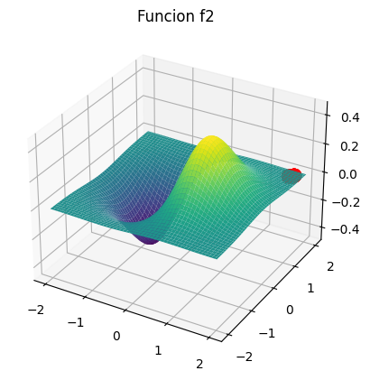

```python
# Punto B Funcion F2

# Creamos la cuadrícula de valores para x1 y x2
x1Vals = np.linspace(-2, 2, 100)
x2Vals = np.linspace(-2, 2, 100)
x1, x2 = np.meshgrid(x1Vals, x2Vals)

# Evaluamos la función en cada punto de la cuadrícula
z = f2(x1, x2)

# Creamos la figura 3D
fig = plt.figure()
ax = fig.add_subplot(111, projection='3d')

# Graficamos la superficie 3D
ax.plot_surface(x1, x2, z, cmap='viridis')
ax.set_title('Funcion f2')

# Ejecutamos la funcion del descenso del gradiente para F1
descenso_gradiente_f2(0.1)

# Mostramos el gráfico
plt.show()
```

```
La cantidad de iteraciones realizadas es:  0
El punto de convergencia alcanzado es:  -1.4 1.1 -0.05880503706482377
Convergio al punto correcto? False
Grafica de los puntos recorridos
```

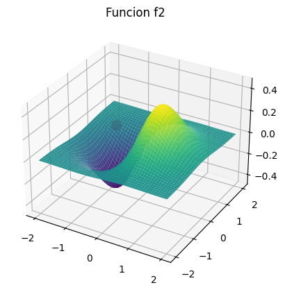

```python
# Punto C Funcion F2

# Creamos la cuadrícula de valores para x1 y x2
x1Vals = np.linspace(-2, 2, 100)
x2Vals = np.linspace(-2, 2, 100)
x1, x2 = np.meshgrid(x1Vals, x2Vals)

# Evaluamos la función en cada punto de la cuadrícula
z = f2(x1, x2)

# Creamos la figura 3D
fig = plt.figure()
ax = fig.add_subplot(111, projection='3d')

# Graficamos la superficie 3D
ax.plot_surface(x1, x2, z, cmap='viridis')
ax.set_title('Funcion f2')

# Ejecutamos la funcion del descenso del gradiente para F1
descenso_gradiente_f2(0.8)

# Mostramos el gráfico
plt.show()
```

```
La cantidad de iteraciones realizadas es:  0
El punto de convergencia alcanzado es:  -1.3 1.5 -0.025282679169001
Convergio al punto correcto? False
Grafica de los puntos recorridos
```

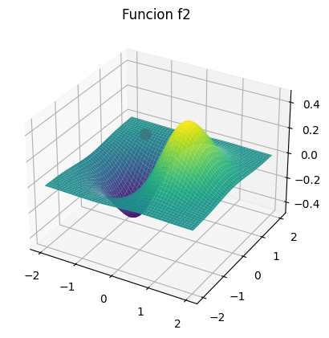

```python
# Punto C Funcion F2

# Creamos la cuadrícula de valores para x1 y x2
x1Vals = np.linspace(-2, 2, 100)
x2Vals = np.linspace(-2, 2, 100)
x1, x2 = np.meshgrid(x1Vals, x2Vals)

# Evaluamos la función en cada punto de la cuadrícula
z = f2(x1, x2)

# Creamos la figura 3D
fig = plt.figure()
ax = fig.add_subplot(111, projection='3d')

# Graficamos la superficie 3D
ax.plot_surface(x1, x2, z, cmap='viridis')
ax.set_title('Funcion f2')

# Ejecutamos la funcion del descenso del gradiente para F1
descenso_gradiente_f2(0.3)

# Mostramos el gráfico
plt.show()
```